# 1.2 WithinPlot:LASSO Regression

2025-06-20

The Goal of this document is to use LASSO regression to tell me which variable I can remove from my GLMM at the within-plot level of this project. I will be looking to cross-validate it as well. Then I can use that model and do my negligible effects magic as well. Aspect is the tricky one (yet again) but by doing a ‘group lasso’ with dummy variables, it should work out!

I may also try to explore Dr. Gilbert’s idea of removing species or group of species and the simulating those results. Perhaps some kind of randomization test could also prove useful.

# **LASSO**-ing

Okay, let’s get the Lasso working.

## *All Plots*

### Data Wrangling

The first thing I have to do is get the data looking nice. I separate out the response variable. Then I select out the predictor variables I have data for every plot on. This has to be a matrix. I’ve set up Aspect as a dummy variable for each and every level. Any weirdness will be solved by grouping my predictors. That’s what the ‘AspectGroup’ does. It will lump all my aspect dummy variables together and leave everyone else alone. The Lasso then will decide to include all or none of the Aspect Dummy variables.

```r
head(Comb_Dis)
```

```
##   Plot Dissimilarity        X         Y          Z Site    SoilTemp  SoilMoist
## 1    1     0.4024599 27.99054 15.291673 0.09103439 TeMi -0.27407649  1.5065314
## 2    2     0.0000000 34.03762  7.180370 0.00000000 TeMi  0.37848659  1.1790246
## 3    3     0.4196000 46.89969  6.040091 3.30817681 TeMi  0.37848659  1.1790246
## 4    4     0.5428571 53.33120 14.105131 4.49339646 TeMi -0.01305126 -0.4585096
## 5    5     0.8193920 44.40650 30.406395 4.34845167 TeMi -0.14356388  0.8515178
## 6    6     0.0000000 35.08873 20.957058 4.65637884 TeMi  0.63951182  0.1965041
##   Slope Aspect     Date Collectors dry_weight   pH cond_us.cm salinity_ppt
## 1 15.84      S 8/8/2022  BJR + ARM      20.00 9.30     1461.0        0.576
## 2  2.71      N 8/8/2022  BJR + ARM      20.02 9.42      941.0        0.287
## 3  1.30      N 8/8/2022  BJR + ARM      20.03 9.12      883.4        0.319
## 4  4.75      S 8/8/2022  BJR + ARM      20.00 9.21      614.8        0.231
## 5  7.71     SE 8/8/2022  BJR + ARM      20.02 8.99      524.9        0.192
## 6 10.09      E 8/8/2022  BJR + ARM      20.02 9.28      740.0        0.262
##                                                   Notes
## 1 highlighted: mixed on 1/27, refrigerated, read on 2/1
## 2                                                  <NA>
## 3                                                  <NA>
## 4                                                  <NA>
## 5                                                  <NA>
## 6                                                  <NA>
```

```r
With_Las <- subset(Comb_Dis, Dissimilarity >0.0) #this just rid of plots that were all sand

Las.y <- With_Las[,2]
DumAspect<-as.matrix(dummy_cols(With_Las, select_columns = "Aspect")[,18:25])
Las.x1<- With_Las %>% select(c( "SoilTemp", "SoilMoist","X", "Y", "Z", "Slope"))

AspectGroup <- c((1:dim(Las.x1)[2]), rep(dim(Las.x1)[2]+1, 8))

Las.x.scaled <- Las.x1
Las.x.scaled$X <- scale(Las.x.scaled$X)
Las.x.scaled$Y <- scale(Las.x.scaled$Y)
Las.x.scaled$Z <- scale(Las.x.scaled$Z)
Las.x.scaled$Slope <- scale(Las.x.scaled$Slope)

Las.x<- Las.x1%>%
  cbind(DumAspect) %>%
  as.matrix()
```

### Actually run the Lasso

Okay, here I’m faced with yet another fork in the road. There is a standard lasso first which gives the coeffecients along a range of Lambdas. That’s good but, then there is the cross validating lasso that used k-fold cross-validation that helps with over fitting. I think that’s the move but then it leaves us with another fork! Do we want the minimum lambda (which is MSE) or a standard error away which one source said can help avoid overfitting. In this case, I don’t think I’m stressed about overfitting so we are minimizing error (also, uh, no coeffecients ever are non-zero in the other one sooooooo year)

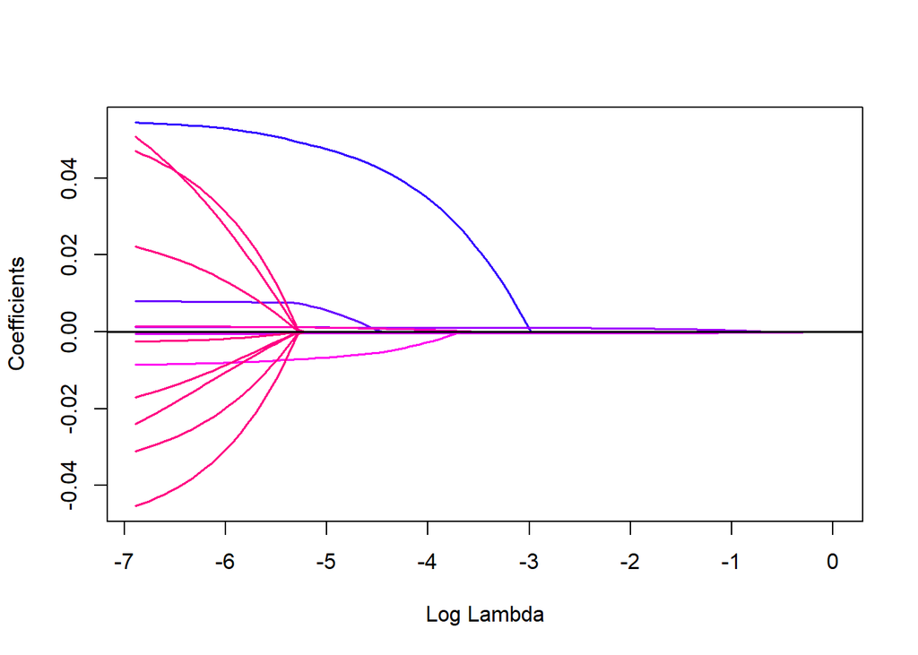

```r
With.Lass<-gglasso(x = Las.x, y = Las.y, group = AspectGroup, loss = "ls")
plot(With.Lass)
```

```r
coef(With.Lass)[,95:100]
```

```
##                       s94           s95           s96           s97
## (Intercept)  0.4615557754  0.4616406062  0.4617031052  0.4617459752
## SoilTemp     0.0540329037  0.0541293903  0.0542172199  0.0542971799
## SoilMoist    0.0079112861  0.0079252634  0.0079389598  0.0079523683
## X            0.0011889495  0.0011916912  0.0011944436  0.0011971882
## Y           -0.0005213058 -0.0005238684 -0.0005262517 -0.0005284679
## Z           -0.0084367633 -0.0084714707 -0.0085034149 -0.0085327708
## Slope        0.0013872373  0.0013944658  0.0014013291  0.0014078389
## Aspect_E    -0.0142571127 -0.0148590176 -0.0154320925 -0.0159764998
## Aspect_N    -0.0023664064 -0.0024000444 -0.0024272323 -0.0024485914
## Aspect_NE   -0.0279043175 -0.0286368236 -0.0293152964 -0.0299434186
## Aspect_NW   -0.0190313240 -0.0200770244 -0.0211030529 -0.0221070937
## Aspect_S     0.0425564147  0.0435849929  0.0445392292  0.0454248646
## Aspect_SE    0.0430899799  0.0447732409  0.0463777902  0.0479050265
## Aspect_SW    0.0193887963  0.0200091104  0.0205946846  0.0211471979
## Aspect_W    -0.0414756149 -0.0423939598 -0.0432334938 -0.0440008283
##                       s98           s99
## (Intercept)  0.4617717404  0.4617826852
## SoilTemp     0.0543699898  0.0544363067
## SoilMoist    0.0079654760  0.0079782695
## X            0.0011999086  0.0012025909
## Y           -0.0005305283 -0.0005324436
## Z           -0.0085597127 -0.0085844081
## Slope        0.0014140069  0.0014198454
## Aspect_E    -0.0164926256 -0.0169810152
## Aspect_N    -0.0024647396 -0.0024762484
## Aspect_NE   -0.0305247058 -0.0310624691
## Aspect_NW   -0.0230870889 -0.0240412226
## Aspect_S     0.0462471399  0.0470108763
## Aspect_SE    0.0493566144  0.0507344764
## Aspect_SW    0.0216682513  0.0221594057
## Aspect_W    -0.0447021053 -0.0453429811
```

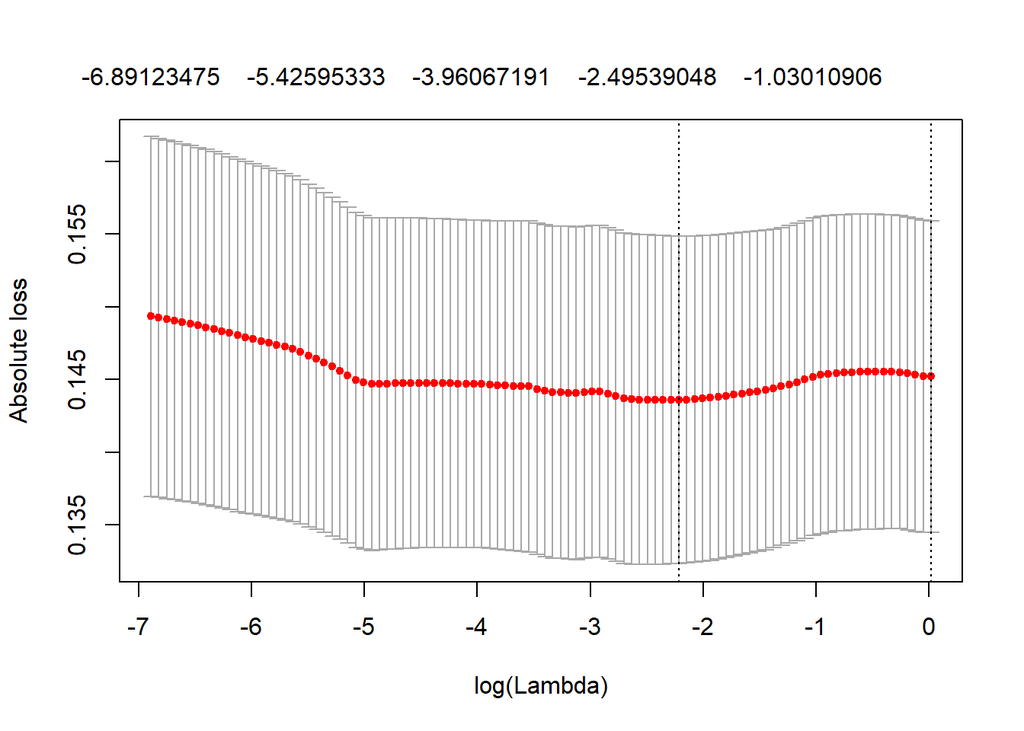

```r
CV.With.Lass<- cv.gglasso(x = Las.x, y = Las.y, group = AspectGroup, pred.loss = "L1")
plot(CV.With.Lass)
```

```r
coef(CV.With.Lass, s = "lambda.min")
```

```
##                         1
## (Intercept)  0.4454063304
## SoilTemp     0.0000000000
## SoilMoist    0.0000000000
## X            0.0009244181
## Y           -0.0003728126
## Z            0.0000000000
## Slope        0.0000000000
## Aspect_E     0.0000000000
## Aspect_N     0.0000000000
## Aspect_NE    0.0000000000
## Aspect_NW    0.0000000000
## Aspect_S     0.0000000000
## Aspect_SE    0.0000000000
## Aspect_SW    0.0000000000
## Aspect_W     0.0000000000
```

```r
coef(CV.With.Lass, s = "lambda.1se")
```

```
##                     1
## (Intercept) 0.4536756
## SoilTemp    0.0000000
## SoilMoist   0.0000000
## X           0.0000000
## Y           0.0000000
## Z           0.0000000
## Slope       0.0000000
## Aspect_E    0.0000000
## Aspect_N    0.0000000
## Aspect_NE   0.0000000
## Aspect_NW   0.0000000
## Aspect_S    0.0000000
## Aspect_SE   0.0000000
## Aspect_SW   0.0000000
## Aspect_W    0.0000000
```

You won’t see it here, but a problem with the cross validation is that it introduces some randomness. If you re run it, it comes to a different solution each time. I solve this a little ways down.

## *All Variables (Soil Data)*

Okay, so, this is the second approach which prioritizes having all variables included at the expense of ~40 plots. Leaving us with a sample size of 64 instead of 107. But the soil data (pH, conductivity, and salinity) may be very important

### Data Wrangling: Removing plots with NA for ph

The Lasso-ing process is much the same here as it was before. The tricky plot was really data wrangling. I’m sure there are a thousand better ways to wrangle but this works for me!

```r
Las.x2<- With_Las %>%
  select(c( "SoilTemp", "SoilMoist","X", "Y", "Z", "Slope", "pH", "cond_us.cm", "salinity_ppt")) %>% na.omit()


DumAspect2<-With_Las %>%
  dummy_cols( select_columns = "Aspect") %>%
  select(Aspect_E:Aspect_W, pH)%>%
  na.omit() %>%
  select(Aspect_E:Aspect_W)


Las.x3<- Las.x2%>%
  cbind(DumAspect2)

dim(Las.x3)
```

```
## [1] 64 17
```

```r
Las.y2 <- With_Las %>%
  select(Dissimilarity, pH) %>%
  na.omit() %>%
  select(Dissimilarity) %>%
  as.matrix()
dim(Las.y2)
```

```
## [1] 64  1
```

```r
AspectGroup2 <- c((1:dim(Las.x2)[2]), rep(dim(Las.x2)[2]+1, 8))
dim(Las.x3)
```

```
## [1] 64 17
```

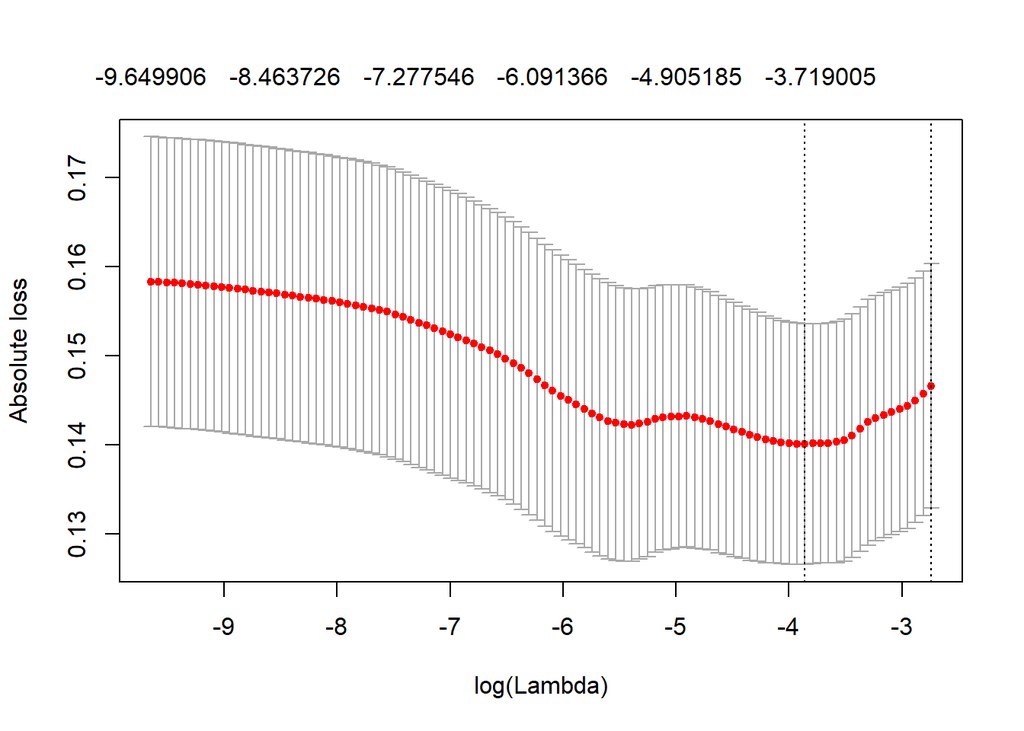

```r
Las.x4 <- Las.x3
Las.x4$cond_us.cm <- scale(Las.x4$cond_us.cm)
Las.x4$X <- scale(Las.x4$X)
Las.x4$Y <- scale(Las.x4$Y)
Las.x4$Z <- scale(Las.x4$Z)
Las.x4$Slope <- scale(Las.x4$Slope)
Las.x4$pH <- scale(Las.x4$pH)
Las.x4$salinity_ppt <- scale(Las.x4$salinity_ppt)




CV.With.Lass.Ph<- cv.gglasso(x = as.matrix(Las.x4), y = Las.y2, group = AspectGroup2, pred.loss = "L1")
plot(CV.With.Lass.Ph)
```

```r
coef(CV.With.Lass.Ph, s = "lambda.min")
```

```
##                         1
## (Intercept)   0.509792125
## SoilTemp      0.044867250
## SoilMoist     0.004608401
## X             0.000000000
## Y             0.000000000
## Z             0.000000000
## Slope         0.000000000
## pH            0.000000000
## cond_us.cm    0.000000000
## salinity_ppt -0.026289691
## Aspect_E      0.000000000
## Aspect_N      0.000000000
## Aspect_NE     0.000000000
## Aspect_NW     0.000000000
## Aspect_S      0.000000000
## Aspect_SE     0.000000000
## Aspect_SW     0.000000000
## Aspect_W      0.000000000
```

```r
coef(CV.With.Lass.Ph, s = "lambda.1se")
```

```
##                      1
## (Intercept)  0.5026862
## SoilTemp     0.0000000
## SoilMoist    0.0000000
## X            0.0000000
## Y            0.0000000
## Z            0.0000000
## Slope        0.0000000
## pH           0.0000000
## cond_us.cm   0.0000000
## salinity_ppt 0.0000000
## Aspect_E     0.0000000
## Aspect_N     0.0000000
## Aspect_NE    0.0000000
## Aspect_NW    0.0000000
## Aspect_S     0.0000000
## Aspect_SE    0.0000000
## Aspect_SW    0.0000000
## Aspect_W     0.0000000
```

Once again, we see that the 1se gives us zeros for everything so we are going proceed with the minimizing of lambda route. I’ve seen people argue for both, so whatever works!

# **Simulating**

Okay, here is where the real magic starts. I noticed that there is some randomness in the cross-validated lasso which makes some sense. So, I figured, why not just run it a bunch of times and count up how often each variable was non-zero. So, that’s what I did!

```r
storage <- data.frame(row.names =  rownames(coef(CV.With.Lass, s = "lambda.1se")))
storage.pH<- data.frame(row.names = rownames(coef(CV.With.Lass.Ph, s = "lambda.1se")))
for(i in 1:10000){

  Loop <- cv.gglasso(x = Las.x, y = Las.y, group = AspectGroup, pred.loss = "L1")
  storage[,i] <-coef(Loop, s = "lambda.min")[,1]

  Loop.pH <- cv.gglasso(x = as.matrix(Las.x4), y = Las.y2, group = AspectGroup2, pred.loss = "L1")
  storage.pH[,i] <-coef(Loop.pH, s = "lambda.min")[,1]

  #print(i)
  i = i+1

}

sim.plots<-rowSums(storage!=0)
sim.vars<-rowSums(storage.pH!=0)

as.data.frame(sort(sim.plots, decreasing = TRUE))
```

```
##             sort(sim.plots, decreasing = TRUE)
## (Intercept)                              10000
## Y                                         9115
## X                                         8930
## SoilTemp                                  6092
## Slope                                     5643
## Z                                         5150
## SoilMoist                                 2158
## Aspect_E                                   595
## Aspect_N                                   595
## Aspect_NE                                  595
## Aspect_NW                                  595
## Aspect_S                                   595
## Aspect_SE                                  595
## Aspect_SW                                  595
## Aspect_W                                   595
```

```r
as.data.frame(sort(sim.vars, decreasing = TRUE))
```

```
##              sort(sim.vars, decreasing = TRUE)
## (Intercept)                              10000
## SoilTemp                                  9705
## salinity_ppt                              9367
## SoilMoist                                 6915
## Y                                         4269
## Slope                                     1623
## Z                                         1058
## Aspect_E                                  1015
## Aspect_N                                  1015
## Aspect_NE                                 1015
## Aspect_NW                                 1015
## Aspect_S                                  1015
## Aspect_SE                                 1015
## Aspect_SW                                 1015
## Aspect_W                                  1015
## X                                          957
## pH                                          59
## cond_us.cm                                  17
```

Okay! I’ve plotted and explained below!

### Plotting the Simulations

Just to make it easier to read

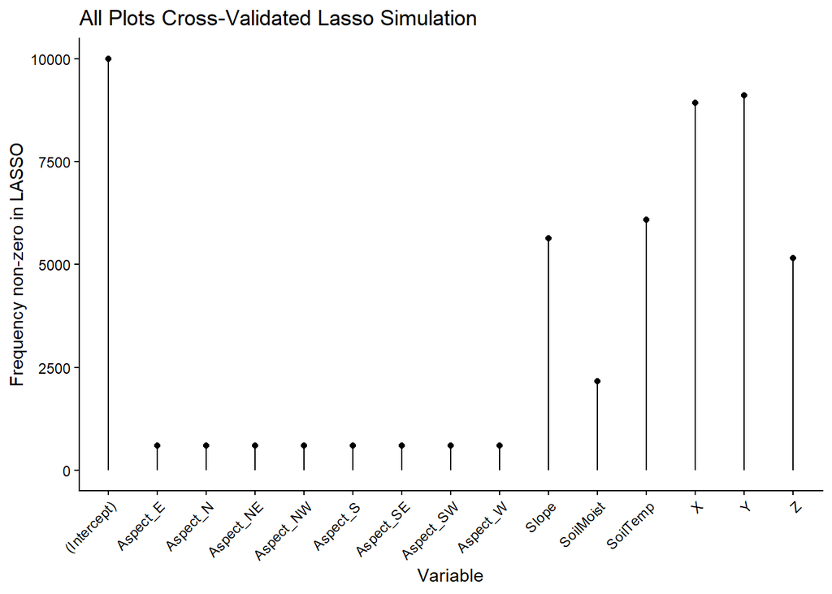

```r
storage.plot<- data.frame(Name = rownames_to_column(storage)[1], totals = rowSums(storage!=0))
storage.pH.plot<- data.frame(Name = rownames_to_column(storage.pH)[1], totals = rowSums(storage.pH!=0))


ggplot(aes(x = rowname, y = totals), data = storage.plot)+
  geom_point()+
  geom_segment( aes(x=rowname, xend=rowname, y=0, yend=totals))+
  scale_x_discrete(guide = guide_axis(angle = 45)) +
  theme_classic()+
  labs(x = "Variable", y = "Frequency non-zero in LASSO", title = "All Plots Cross-Validated Lasso Simulation")
```

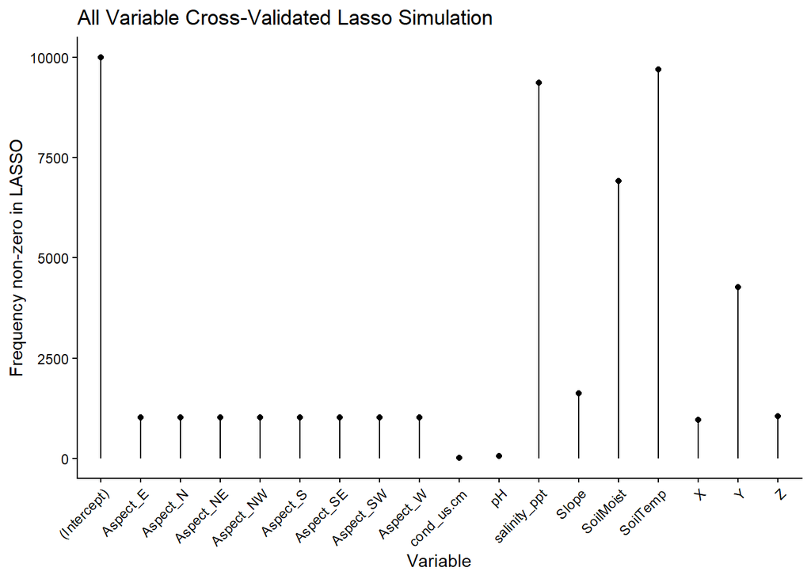

```r
ggplot(aes(x = rowname, y = totals), data = storage.pH.plot)+
  geom_point()+
  geom_segment( aes(x=rowname, xend=rowname, y=0, yend=totals))+
  scale_x_discrete(guide = guide_axis(angle = 45)) +
  theme_classic()+
  labs(x = "Variable", y = "Frequency non-zero in LASSO", title = "All Variable Cross-Validated Lasso Simulation")
```

This is where everything clicked into place for me! Having the all variable simulation spit out only four variables that matter helped guide me in the all plots variant. Starting with the four most common variable in the all plots area was great guidance!

# **Using LASSO**

Now that I have my starting points! I can do more classic model selection where I can really justify what I’m doing and why.

## *All Plots*

The simulation for the All Plots direction spit our the Y axis (which is weird bc it shouldn’t matter), the X axis (distance from waterline), Soil Temperature (it simply had to), and Slope (Okay) as the variables that most frequently mattered. That’s a great place to start!

### Model Selection

So, here’s the deal. I have known that Soil Temperature is the only thing that matter, but I haven’t been able to justify what model to put it in and how I got there. A full model was being beaten by a null model and that wasn’t right. Here, I put all four in a model then compared it to a null model and then each of the four individually and none of them beat them (some tied, but I think I can justify keeping the full). I then did the same negligible effects plot and everything as before!

```r
Lasso.plots.full <- lmer(Dissimilarity ~ Y + X + SoilTemp + Slope + Z + SoilMoist + (1|Site), data = With_Las)
Lasso.plots.reduced <- lmer(Dissimilarity ~ Y + X + SoilTemp + Slope + Z  + (1|Site), data = With_Las)
Lasso.plots.reduceder <- lmer(Dissimilarity ~ Y + X  +(1|Site), data = With_Las)

Lasso.plots.null <- lmer(Dissimilarity ~ 1  + (1|Site), data = With_Las)
Lasso.plots.ST<- lmer(Dissimilarity ~ SoilTemp  + (1|Site), data = With_Las)
Lasso.plots.Y<- lmer(Dissimilarity ~ Y  + (1|Site), data = With_Las)
Lasso.plots.X<- lmer(Dissimilarity ~ X  + (1|Site), data = With_Las)
Lasso.plots.Slope<- lmer(Dissimilarity ~ Slope  + (1|Site), data = With_Las)
Lasso.plots.Z<- lmer(Dissimilarity ~ Z  + (1|Site), data = With_Las)

summary(Lasso.plots.full)
```

```
## Linear mixed model fit by REML ['lmerMod']
## Formula: Dissimilarity ~ Y + X + SoilTemp + Slope + Z + SoilMoist + (1 |
##     Site)
##    Data: With_Las
##
## REML criterion at convergence: -22
##
## Scaled residuals:
##     Min      1Q  Median      3Q     Max
## -2.0479 -0.6708 -0.2105  0.5117  3.2669
##
## Random effects:
##  Groups   Name        Variance Std.Dev.
##  Site     (Intercept) 0.005381 0.07336
##  Residual             0.026948 0.16416
## Number of obs: 107, groups:  Site, 3
##
## Fixed effects:
##               Estimate Std. Error t value
## (Intercept)  0.4822190  0.0802742   6.007
## Y           -0.0003867  0.0003290  -1.175
## X            0.0009130  0.0008311   1.099
## SoilTemp     0.0575506  0.0169660   3.392
## Slope        0.0007132  0.0018002   0.396
## Z           -0.0096759  0.0106459  -0.909
## SoilMoist    0.0089991  0.0183821   0.490
##
## Correlation of Fixed Effects:
##           (Intr) Y      X      SolTmp Slope  Z
## Y         -0.364
## X         -0.488  0.041
## SoilTemp  -0.049 -0.011 -0.076
## Slope     -0.355 -0.073  0.105  0.239
## Z         -0.497  0.070  0.004  0.067  0.028
## SoilMoist -0.357  0.088  0.422 -0.013  0.185  0.180
```

```r
r.squaredGLMM(Lasso.plots.full)
```

```
##            R2m       R2c
## [1,] 0.1157993 0.2629763
```

```r
anova(Lasso.plots.full, Lasso.plots.null)
```

```
## refitting model(s) with ML (instead of REML)
```

```
## Data: With_Las
## Models:
## Lasso.plots.null: Dissimilarity ~ 1 + (1 | Site)
## Lasso.plots.full: Dissimilarity ~ Y + X + SoilTemp + Slope + Z + SoilMoist + (1 | Site)
##                  npar     AIC     BIC logLik -2*log(L)  Chisq Df Pr(>Chisq)
## Lasso.plots.null    3 -62.006 -53.987 34.003   -68.006
## Lasso.plots.full    9 -66.187 -42.131 42.093   -84.187 16.181  6    0.01282 *
## ---
## Signif. codes:  0 '***' 0.001 '**' 0.01 '*' 0.05 '.' 0.1 ' ' 1
```

```r
anova(Lasso.plots.full, Lasso.plots.ST) #technically has a lower AIC, but not sig
```

```
## refitting model(s) with ML (instead of REML)
```

```
## Data: With_Las
## Models:
## Lasso.plots.ST: Dissimilarity ~ SoilTemp + (1 | Site)
## Lasso.plots.full: Dissimilarity ~ Y + X + SoilTemp + Slope + Z + SoilMoist + (1 | Site)
##                  npar     AIC     BIC logLik -2*log(L) Chisq Df Pr(>Chisq)
## Lasso.plots.ST      4 -72.459 -61.767 40.229   -80.459
## Lasso.plots.full    9 -66.187 -42.131 42.093   -84.187 3.728  5     0.5892
```

```r
anova(Lasso.plots.reduced, Lasso.plots.ST)
```

```
## refitting model(s) with ML (instead of REML)
```

```
## Data: With_Las
## Models:
## Lasso.plots.ST: Dissimilarity ~ SoilTemp + (1 | Site)
## Lasso.plots.reduced: Dissimilarity ~ Y + X + SoilTemp + Slope + Z + (1 | Site)
##                     npar     AIC     BIC logLik -2*log(L)  Chisq Df Pr(>Chisq)
## Lasso.plots.ST         4 -72.459 -61.767 40.229   -80.459
## Lasso.plots.reduced    8 -67.913 -46.530 41.957   -83.913 3.4545  4     0.4848
```

```r
anova(Lasso.plots.full, Lasso.plots.Y)
```

```
## refitting model(s) with ML (instead of REML)
```

```
## Data: With_Las
## Models:
## Lasso.plots.Y: Dissimilarity ~ Y + (1 | Site)
## Lasso.plots.full: Dissimilarity ~ Y + X + SoilTemp + Slope + Z + SoilMoist + (1 | Site)
##                  npar     AIC     BIC logLik -2*log(L)  Chisq Df Pr(>Chisq)
## Lasso.plots.Y       4 -61.329 -50.637 34.664   -69.329
## Lasso.plots.full    9 -66.187 -42.131 42.093   -84.187 14.858  5    0.01099 *
## ---
## Signif. codes:  0 '***' 0.001 '**' 0.01 '*' 0.05 '.' 0.1 ' ' 1
```

```r
anova(Lasso.plots.full, Lasso.plots.X)
```

```
## refitting model(s) with ML (instead of REML)
```

```
## Data: With_Las
## Models:
## Lasso.plots.X: Dissimilarity ~ X + (1 | Site)
## Lasso.plots.full: Dissimilarity ~ Y + X + SoilTemp + Slope + Z + SoilMoist + (1 | Site)
##                  npar     AIC     BIC logLik -2*log(L)  Chisq Df Pr(>Chisq)
## Lasso.plots.X       4 -61.416 -50.725 34.708   -69.416
## Lasso.plots.full    9 -66.187 -42.131 42.093   -84.187 14.771  5    0.01139 *
## ---
## Signif. codes:  0 '***' 0.001 '**' 0.01 '*' 0.05 '.' 0.1 ' ' 1
```

```r
anova(Lasso.plots.full, Lasso.plots.Slope)
```

```
## refitting model(s) with ML (instead of REML)
```

```
## Data: With_Las
## Models:
## Lasso.plots.Slope: Dissimilarity ~ Slope + (1 | Site)
## Lasso.plots.full: Dissimilarity ~ Y + X + SoilTemp + Slope + Z + SoilMoist + (1 | Site)
##                   npar     AIC     BIC logLik -2*log(L)  Chisq Df Pr(>Chisq)
## Lasso.plots.Slope    4 -60.443 -49.752 34.222   -68.443
## Lasso.plots.full     9 -66.187 -42.131 42.093   -84.187 15.743  5   0.007616 **
## ---
## Signif. codes:  0 '***' 0.001 '**' 0.01 '*' 0.05 '.' 0.1 ' ' 1
```

```r
anova(Lasso.plots.full, Lasso.plots.Z)
```

```
## refitting model(s) with ML (instead of REML)
```

```
## Data: With_Las
## Models:
## Lasso.plots.Z: Dissimilarity ~ Z + (1 | Site)
## Lasso.plots.full: Dissimilarity ~ Y + X + SoilTemp + Slope + Z + SoilMoist + (1 | Site)
##                  npar     AIC     BIC logLik -2*log(L)  Chisq Df Pr(>Chisq)
## Lasso.plots.Z       4 -61.105 -50.414 34.552   -69.105
## Lasso.plots.full    9 -66.187 -42.131 42.093   -84.187 15.082  5    0.01002 *
## ---
## Signif. codes:  0 '***' 0.001 '**' 0.01 '*' 0.05 '.' 0.1 ' ' 1
```

```r
anova(Lasso.plots.full, Lasso.plots.reduced)
```

```
## refitting model(s) with ML (instead of REML)
```

```
## Data: With_Las
## Models:
## Lasso.plots.reduced: Dissimilarity ~ Y + X + SoilTemp + Slope + Z + (1 | Site)
## Lasso.plots.full: Dissimilarity ~ Y + X + SoilTemp + Slope + Z + SoilMoist + (1 | Site)
##                     npar     AIC     BIC logLik -2*log(L)  Chisq Df Pr(>Chisq)
## Lasso.plots.reduced    8 -67.913 -46.530 41.957   -83.913
## Lasso.plots.full       9 -66.187 -42.131 42.093   -84.187 0.2735  1      0.601
```

```r
anova(Lasso.plots.full, Lasso.plots.reduceder)
```

```
## refitting model(s) with ML (instead of REML)
```

```
## Data: With_Las
## Models:
## Lasso.plots.reduceder: Dissimilarity ~ Y + X + (1 | Site)
## Lasso.plots.full: Dissimilarity ~ Y + X + SoilTemp + Slope + Z + SoilMoist + (1 | Site)
##                       npar     AIC     BIC logLik -2*log(L)  Chisq Df
## Lasso.plots.reduceder    5 -60.722 -47.357 35.361   -70.722
## Lasso.plots.full         9 -66.187 -42.131 42.093   -84.187 13.465  4
##                       Pr(>Chisq)
## Lasso.plots.reduceder
## Lasso.plots.full        0.009214 **
## ---
## Signif. codes:  0 '***' 0.001 '**' 0.01 '*' 0.05 '.' 0.1 ' ' 1
```

```r
anova(Lasso.plots.reduced, Lasso.plots.reduceder)
```

```
## refitting model(s) with ML (instead of REML)
```

```
## Data: With_Las
## Models:
## Lasso.plots.reduceder: Dissimilarity ~ Y + X + (1 | Site)
## Lasso.plots.reduced: Dissimilarity ~ Y + X + SoilTemp + Slope + Z + (1 | Site)
##                       npar     AIC     BIC logLik -2*log(L)  Chisq Df
## Lasso.plots.reduceder    5 -60.722 -47.357 35.361   -70.722
## Lasso.plots.reduced      8 -67.913 -46.530 41.957   -83.913 13.191  3
##                       Pr(>Chisq)
## Lasso.plots.reduceder
## Lasso.plots.reduced      0.00424 **
## ---
## Signif. codes:  0 '***' 0.001 '**' 0.01 '*' 0.05 '.' 0.1 ' ' 1
```

```r
library(cAIC4)

cAIC(Lasso.plots.full)
```

```
##
##                Conditional log-likelihood:   45.87
##                        Degrees of freedom:    9.94
##  Conditional Akaike information criterion:  -71.85
```

```r
cAIC(Lasso.plots.null)
```

```
##
##                Conditional log-likelihood:   37.67
##                        Degrees of freedom:    3.97
##  Conditional Akaike information criterion:  -67.40
```

```r
cAIC(Lasso.plots.reduced)
```

```
##
##                Conditional log-likelihood:   45.81
##                        Degrees of freedom:    8.95
##  Conditional Akaike information criterion:  -73.71
```

```r
cAIC(Lasso.plots.reduceder)$caic
```

```
## [1] -65.84424
```

Technically the Soil Temperature alone model has a lower AIC, but not significantly so!

### Another Attempt at model Selection

###### Okay, I tried another model selection approach

```r
Lasso.plots.null <- lmer(Dissimilarity ~ 1  + (1|Site), data = With_Las)

Lasso.plots.Y<- lmer(Dissimilarity ~ Y  + (1|Site), data = With_Las)

anova(Lasso.plots.Y, Lasso.plots.null)
```

```
## refitting model(s) with ML (instead of REML)
```

```
## Data: With_Las
## Models:
## Lasso.plots.null: Dissimilarity ~ 1 + (1 | Site)
## Lasso.plots.Y: Dissimilarity ~ Y + (1 | Site)
##                  npar     AIC     BIC logLik -2*log(L)  Chisq Df Pr(>Chisq)
## Lasso.plots.null    3 -62.006 -53.987 34.003   -68.006
## Lasso.plots.Y       4 -61.329 -50.637 34.664   -69.329 1.3226  1     0.2501
```

```r
anova(Lasso.plots.X, Lasso.plots.null)
```

```
## refitting model(s) with ML (instead of REML)
```

```
## Data: With_Las
## Models:
## Lasso.plots.null: Dissimilarity ~ 1 + (1 | Site)
## Lasso.plots.X: Dissimilarity ~ X + (1 | Site)
##                  npar     AIC     BIC logLik -2*log(L) Chisq Df Pr(>Chisq)
## Lasso.plots.null    3 -62.006 -53.987 34.003   -68.006
## Lasso.plots.X       4 -61.416 -50.725 34.708   -69.416  1.41  1     0.2351
```

```r
Lasso.plots.YXst<- lmer(Dissimilarity ~ Y + X + SoilTemp + (1|Site), data = With_Las)


anova(Lasso.plots.YXst, Lasso.plots.null)
```

```
## refitting model(s) with ML (instead of REML)
```

```
## Data: With_Las
## Models:
## Lasso.plots.null: Dissimilarity ~ 1 + (1 | Site)
## Lasso.plots.YXst: Dissimilarity ~ Y + X + SoilTemp + (1 | Site)
##                  npar     AIC     BIC logLik -2*log(L)  Chisq Df Pr(>Chisq)
## Lasso.plots.null    3 -62.006 -53.987 34.003   -68.006
## Lasso.plots.YXst    6 -70.728 -54.691 41.364   -82.728 14.722  3   0.002071 **
## ---
## Signif. codes:  0 '***' 0.001 '**' 0.01 '*' 0.05 '.' 0.1 ' ' 1
```

```r
Lasso.plots.YXstSlopeZ<- lmer(Dissimilarity ~ Y + X + SoilTemp + Slope+ Z+ (1|Site), data = With_Las)
anova(Lasso.plots.YXst, Lasso.plots.YXstSlopeZ)
```

```
## refitting model(s) with ML (instead of REML)
```

```
## Data: With_Las
## Models:
## Lasso.plots.YXst: Dissimilarity ~ Y + X + SoilTemp + (1 | Site)
## Lasso.plots.YXstSlopeZ: Dissimilarity ~ Y + X + SoilTemp + Slope + Z + (1 | Site)
##                        npar     AIC     BIC logLik -2*log(L)  Chisq Df
## Lasso.plots.YXst          6 -70.728 -54.691 41.364   -82.728
## Lasso.plots.YXstSlopeZ    8 -67.913 -46.530 41.957   -83.913 1.1856  2
##                        Pr(>Chisq)
## Lasso.plots.YXst
## Lasso.plots.YXstSlopeZ     0.5528
```

### Negligbile effects

Same process as before and same story 😍

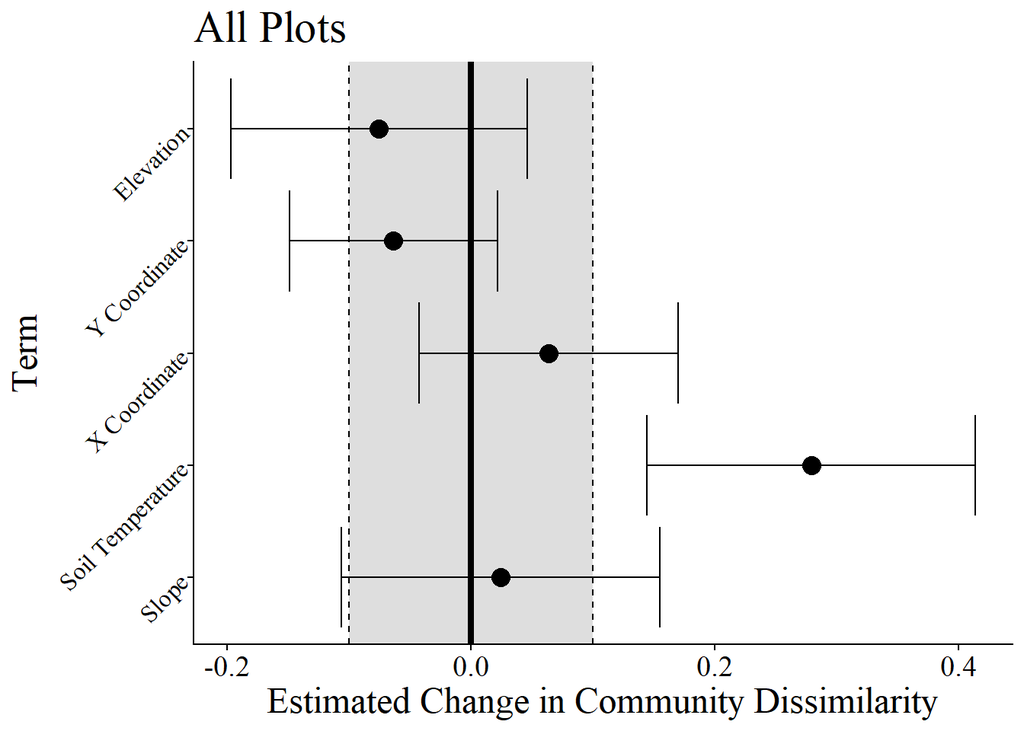

```r
Lasso.cmp<- avg_comparisons(Lasso.plots.reduced, variables = list(Y = "minmax", X = "minmax", SoilTemp = "minmax", Slope = "minmax", Z = "minmax"),   conf_level = 0.90, type = "response")
Lasso.cmp <- as.data.frame(Lasso.cmp)

Comb_Dis$Site <- factor(Comb_Dis$Site, levels=c('TeMi', 'Zmud', 'GuNi'))


Plots.Negl<-   ggplot(Lasso.cmp, aes(x = estimate,
                 xmin = conf.low,
                 xmax = conf.high,
                 y = term,
                 group = contrast)) +
     annotate("rect", xmin = -0.1, xmax = 0.1, ymin = -Inf, ymax = Inf, alpha = .2)+
  geom_vline(xintercept = c(-0.1, .1), linetype = "dashed") +
  geom_vline(xintercept = 0, linetype = "solid", linewidth = 1.5)+
  geom_errorbarh(aes(xmin = conf.low,  xmax = conf.high,)) +
  geom_point(size = 4) +
  theme_classic()+
  labs(x = "Estimated Change in Community Dissimilarity", y = "Term", title = "All Plots")+
  theme(text = element_text(family = "serif", size = 18), axis.text.y = element_text( size=12, angle=45))+
  scale_y_discrete(labels=c("Z" = "Elevation",
                            "Y" = "Y Coordinate",
                            "X" = "X Coordinate",
                            "SoilTemp" = "Soil Temperature",
                            "Slope" = "Slope"))
Plots.Negl
```

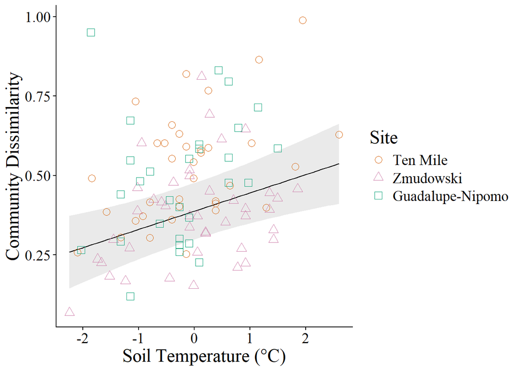

```r
Plots.ST<- plot_predictions(Lasso.plots.full, condition = "SoilTemp")+
  geom_point(data = subset(Comb_Dis, Dissimilarity >0), size = 3,aes(x = SoilTemp, y = Dissimilarity, color = Site, shape = Site))+
  labs(x = paste0("Soil Temperature (", "\u00B0", "C)"), y =  "Community Dissimilarity")+
  scale_color_manual(labels = c("Ten Mile", "Zmudowski", "Guadalupe-Nipomo"), values = c("#d55e00", "#cc79a7", "#009e73"), name = "Site")+
  scale_shape_manual(labels = c("Ten Mile", "Zmudowski", "Guadalupe-Nipomo"), values = c(1,2,0), name = "Site")+
  theme_classic()+
  theme( text = element_text(family = "serif", size = 18))
Plots.ST
```

## *All Variables*

### Model Selection

```r
With_Las_Soil <- subset(With_Las, !is.na(cond_us.cm))

With_Las_Soil$Site <-  factor(With_Las_Soil$Site, levels=c('TeMi',  'GuNi'))


Lasso.vars.full <- lmer(Dissimilarity ~ salinity_ppt + SoilTemp + SoilMoist + Y + (1|Site), data = With_Las_Soil)
Lasso.vars.reduced <- lmer(Dissimilarity ~ salinity_ppt + SoilTemp + SoilMoist  + (1|Site), data = With_Las_Soil)

Lasso.vars.null <- lmer(Dissimilarity ~ 1  + (1|Site), data = With_Las_Soil)
```

```
## boundary (singular) fit: see help('isSingular')
```

```r
Lasso.vars.ST<- lmer(Dissimilarity ~ SoilTemp  + (1|Site), data = With_Las_Soil)
```

```
## boundary (singular) fit: see help('isSingular')
```

```r
Lasso.vars.Y<- lmer(Dissimilarity ~ Y  + (1|Site), data = With_Las_Soil)
```

```
## boundary (singular) fit: see help('isSingular')
```

```r
Lasso.vars.SoilMoist<- lmer(Dissimilarity ~ SoilMoist  + (1|Site), data = With_Las_Soil)
Lasso.vars.salinity<- lmer(Dissimilarity ~ salinity_ppt  + (1|Site), data = With_Las_Soil)
```

```
## boundary (singular) fit: see help('isSingular')
```

```r
summary(Lasso.vars.full)
```

```
## Linear mixed model fit by REML ['lmerMod']
## Formula: Dissimilarity ~ salinity_ppt + SoilTemp + SoilMoist + Y + (1 |
##     Site)
##    Data: With_Las_Soil
##
## REML criterion at convergence: -17.9
##
## Scaled residuals:
##     Min      1Q  Median      3Q     Max
## -1.5035 -0.6853 -0.2767  0.5848  3.0415
##
## Random effects:
##  Groups   Name        Variance Std.Dev.
##  Site     (Intercept) 0.002446 0.04946
##  Residual             0.027384 0.16548
## Number of obs: 64, groups:  Site, 2
##
## Fixed effects:
##                Estimate Std. Error t value
## (Intercept)   0.6404873  0.0653067   9.807
## salinity_ppt -0.1997021  0.0810485  -2.464
## SoilTemp      0.0674879  0.0222131   3.038
## SoilMoist     0.0295866  0.0220981   1.339
## Y            -0.0003492  0.0004503  -0.775
##
## Correlation of Fixed Effects:
##             (Intr) slnty_ SolTmp SolMst
## salinty_ppt -0.536
## SoilTemp     0.128  0.062
## SoilMoist    0.059 -0.265 -0.164
## Y           -0.481 -0.149 -0.194  0.164
```

```r
r.squaredGLMM(Lasso.vars.full)
```

```
##            R2m       R2c
## [1,] 0.2567292 0.3176742
```

```r
anova(Lasso.vars.full, Lasso.vars.null)
```

```
## refitting model(s) with ML (instead of REML)
```

```
## Data: With_Las_Soil
## Models:
## Lasso.vars.null: Dissimilarity ~ 1 + (1 | Site)
## Lasso.vars.full: Dissimilarity ~ salinity_ppt + SoilTemp + SoilMoist + Y + (1 | Site)
##                 npar     AIC     BIC logLik -2*log(L)  Chisq Df Pr(>Chisq)
## Lasso.vars.null    3 -29.949 -23.473 17.975   -35.949
## Lasso.vars.full    7 -38.495 -23.383 26.247   -52.495 16.546  4   0.002368 **
## ---
## Signif. codes:  0 '***' 0.001 '**' 0.01 '*' 0.05 '.' 0.1 ' ' 1
```

```r
anova(Lasso.vars.reduced, Lasso.vars.null)
```

```
## refitting model(s) with ML (instead of REML)
```

```
## Data: With_Las_Soil
## Models:
## Lasso.vars.null: Dissimilarity ~ 1 + (1 | Site)
## Lasso.vars.reduced: Dissimilarity ~ salinity_ppt + SoilTemp + SoilMoist + (1 | Site)
##                    npar     AIC     BIC logLik -2*log(L)  Chisq Df Pr(>Chisq)
## Lasso.vars.null       3 -29.949 -23.473 17.975   -35.949
## Lasso.vars.reduced    6 -39.874 -26.921 25.937   -51.874 15.925  3   0.001175
##
## Lasso.vars.null
## Lasso.vars.reduced **
## ---
## Signif. codes:  0 '***' 0.001 '**' 0.01 '*' 0.05 '.' 0.1 ' ' 1
```

```r
anova(Lasso.vars.full, Lasso.vars.ST)
```

```
## refitting model(s) with ML (instead of REML)
```

```
## Data: With_Las_Soil
## Models:
## Lasso.vars.ST: Dissimilarity ~ SoilTemp + (1 | Site)
## Lasso.vars.full: Dissimilarity ~ salinity_ppt + SoilTemp + SoilMoist + Y + (1 | Site)
##                 npar     AIC     BIC logLik -2*log(L)  Chisq Df Pr(>Chisq)
## Lasso.vars.ST      4 -37.196 -28.560 22.598   -45.196
## Lasso.vars.full    7 -38.495 -23.383 26.247   -52.495 7.2993  3    0.06295 .
## ---
## Signif. codes:  0 '***' 0.001 '**' 0.01 '*' 0.05 '.' 0.1 ' ' 1
```

```r
anova(Lasso.vars.reduced, Lasso.vars.ST)
```

```
## refitting model(s) with ML (instead of REML)
```

```
## Data: With_Las_Soil
## Models:
## Lasso.vars.ST: Dissimilarity ~ SoilTemp + (1 | Site)
## Lasso.vars.reduced: Dissimilarity ~ salinity_ppt + SoilTemp + SoilMoist + (1 | Site)
##                    npar     AIC     BIC logLik -2*log(L)  Chisq Df Pr(>Chisq)
## Lasso.vars.ST         4 -37.196 -28.560 22.598   -45.196
## Lasso.vars.reduced    6 -39.874 -26.921 25.937   -51.874 6.6782  2    0.03547 *
## ---
## Signif. codes:  0 '***' 0.001 '**' 0.01 '*' 0.05 '.' 0.1 ' ' 1
```

```r
anova(Lasso.vars.full, Lasso.vars.Y)
```

```
## refitting model(s) with ML (instead of REML)
```

```
## Data: With_Las_Soil
## Models:
## Lasso.vars.Y: Dissimilarity ~ Y + (1 | Site)
## Lasso.vars.full: Dissimilarity ~ salinity_ppt + SoilTemp + SoilMoist + Y + (1 | Site)
##                 npar     AIC     BIC logLik -2*log(L)  Chisq Df Pr(>Chisq)
## Lasso.vars.Y       4 -28.457 -19.821 18.229   -36.457
## Lasso.vars.full    7 -38.495 -23.383 26.247   -52.495 16.038  3   0.001114 **
## ---
## Signif. codes:  0 '***' 0.001 '**' 0.01 '*' 0.05 '.' 0.1 ' ' 1
```

```r
anova(Lasso.vars.full, Lasso.vars.SoilMoist)
```

```
## refitting model(s) with ML (instead of REML)
```

```
## Data: With_Las_Soil
## Models:
## Lasso.vars.SoilMoist: Dissimilarity ~ SoilMoist + (1 | Site)
## Lasso.vars.full: Dissimilarity ~ salinity_ppt + SoilTemp + SoilMoist + Y + (1 | Site)
##                      npar     AIC     BIC logLik -2*log(L)  Chisq Df Pr(>Chisq)
## Lasso.vars.SoilMoist    4 -29.159 -20.523 18.579   -37.159
## Lasso.vars.full         7 -38.495 -23.383 26.247   -52.495 15.336  3   0.001551
##
## Lasso.vars.SoilMoist
## Lasso.vars.full      **
## ---
## Signif. codes:  0 '***' 0.001 '**' 0.01 '*' 0.05 '.' 0.1 ' ' 1
```

```r
anova(Lasso.vars.full, Lasso.vars.salinity)
```

```
## refitting model(s) with ML (instead of REML)
```

```
## Data: With_Las_Soil
## Models:
## Lasso.vars.salinity: Dissimilarity ~ salinity_ppt + (1 | Site)
## Lasso.vars.full: Dissimilarity ~ salinity_ppt + SoilTemp + SoilMoist + Y + (1 | Site)
##                     npar     AIC     BIC logLik -2*log(L)  Chisq Df Pr(>Chisq)
## Lasso.vars.salinity    4 -32.627 -23.992 20.314   -40.627
## Lasso.vars.full        7 -38.495 -23.383 26.247   -52.495 11.868  3    0.00785
##
## Lasso.vars.salinity
## Lasso.vars.full     **
## ---
## Signif. codes:  0 '***' 0.001 '**' 0.01 '*' 0.05 '.' 0.1 ' ' 1
```

```r
anova(Lasso.vars.full, Lasso.vars.reduced)
```

```
## refitting model(s) with ML (instead of REML)
```

```
## Data: With_Las_Soil
## Models:
## Lasso.vars.reduced: Dissimilarity ~ salinity_ppt + SoilTemp + SoilMoist + (1 | Site)
## Lasso.vars.full: Dissimilarity ~ salinity_ppt + SoilTemp + SoilMoist + Y + (1 | Site)
##                    npar     AIC     BIC logLik -2*log(L)  Chisq Df Pr(>Chisq)
## Lasso.vars.reduced    6 -39.874 -26.921 25.937   -51.874
## Lasso.vars.full       7 -38.495 -23.383 26.247   -52.495 0.6211  1     0.4306
```

Same story with Soil Temperature. Reduced model had lowest AIC

### Negligible effects

```r
Lasso.vars.cmp<- avg_comparisons(Lasso.vars.reduced, variables = list(SoilTemp = "minmax", salinity_ppt  = "minmax", SoilMoist  = "minmax"),   conf_level = 0.90, type = "response")
```

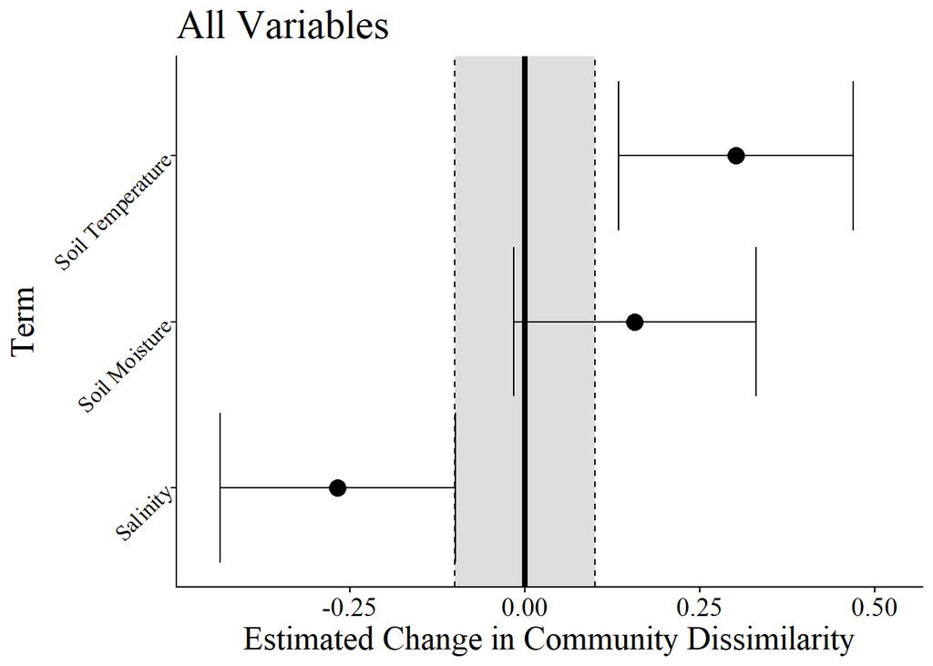

```r
Lasso.vars.cmp <- as.data.frame(Lasso.vars.cmp)

Vars.Negl<- ggplot(Lasso.vars.cmp, aes(x = estimate,
                 xmin = conf.low,
                 xmax = conf.high,
                 y = term,
                 group = contrast)) +
     annotate("rect", xmin = -0.1, xmax = 0.1, ymin = -Inf, ymax = Inf, alpha = .2)+
  geom_vline(xintercept = c(-0.1, .1), linetype = "dashed") +
  geom_vline(xintercept = 0, linetype = "solid", linewidth = 1.5)+
  geom_errorbarh(aes(xmin = conf.low,  xmax = conf.high,)) +
  geom_point(size = 4) +
  theme_classic()+
  labs(x = "Estimated Change in Community Dissimilarity", y = "Term", title = "All Variables")+
  theme(text = element_text(family = "serif", size = 18), axis.text.y = element_text( size=12, angle=45))+
  scale_y_discrete(labels=c("SoilMoist" = "Soil Moisture",
                            "salinity_ppt" = "Salinity",
                            "SoilTemp" = "Soil Temperature"))+
  xlim(-.45, .52)
Vars.Negl
```

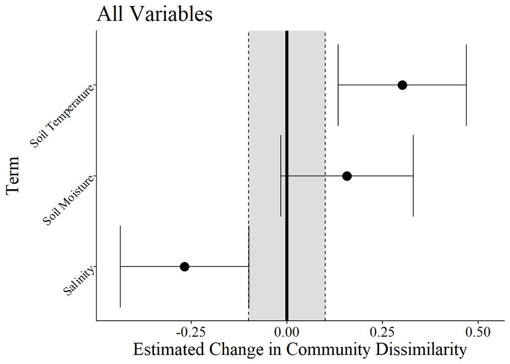

```r
Vars.ST<- plot_predictions(Lasso.vars.reduced, condition = "SoilTemp")+
  geom_point(data = With_Las_Soil, size = 3,aes(x = SoilTemp, y = Dissimilarity, color = Site, shape = Site))+
  labs(x = paste0("Soil Temperature (", "\u00B0", "C)"), y =  "Community Dissimilarity")+
  scale_color_manual(labels = c("Ten Mile", "Guadalupe-Nipomo"), values = c("#d55e00", "#009e73"), name = "Site")+
  scale_shape_manual(labels = c("Ten Mile", "Guadalupe-Nipomo"), values = c(1,0), name = "Site")+
  theme_classic()+
  theme(text = element_text(family = "serif", size = 18))
Vars.SM<- plot_predictions(Lasso.vars.reduced, condition = "SoilMoist")+
  geom_point(data = With_Las_Soil, size = 3,aes(x = SoilMoist, y = Dissimilarity, color = Site, shape = Site))+
  labs(x = "Soil Moisture (%)", y =  "Community Dissimilarity")+
  scale_color_manual(labels = c("Ten Mile", "Guadalupe-Nipomo"), values = c("#d55e00", "#009e73"), name = "Site")+
  scale_shape_manual(labels = c("Ten Mile", "Guadalupe-Nipomo"), values = c(1,0), name = "Site")+
  theme_classic()+
  theme(text = element_text(family = "serif", size = 18))
Vars.Salin<- plot_predictions(Lasso.vars.reduced, condition = "salinity_ppt")+
  geom_point(data = With_Las_Soil, size = 3,aes(x = salinity_ppt, y = Dissimilarity, color = Site, shape = Site))+
  labs(x = "Soil Salinity (ppt)", y =  "Community Dissimilarity")+
  scale_color_manual(labels = c("Ten Mile", "Guadalupe-Nipomo"), values = c("#d55e00", "#009e73"), name = "Site")+
  scale_shape_manual(labels = c("Ten Mile", "Guadalupe-Nipomo"), values = c(1,0), name = "Site")+
  theme_classic()+
  theme(text = element_text(family = "serif", size = 18))
Vars.Negl
```

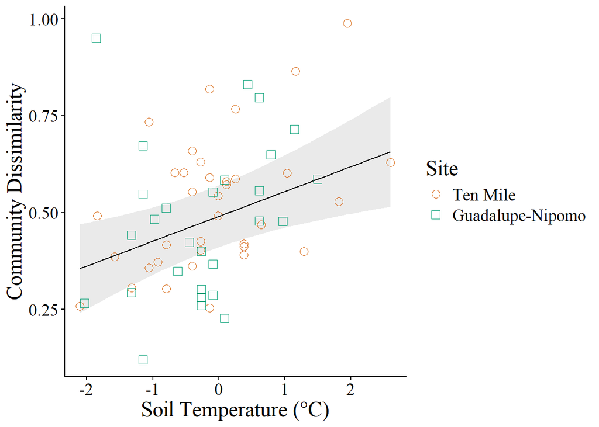

```r
Vars.ST
```

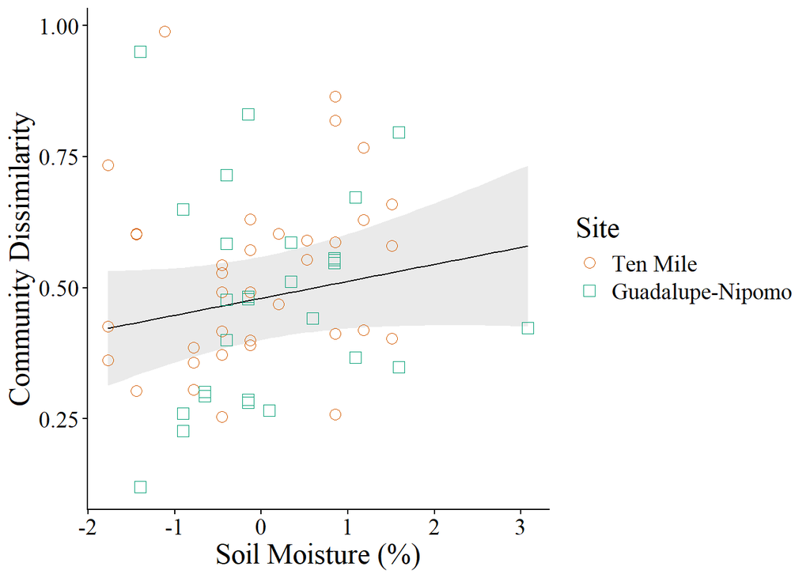

```r
Vars.SM
```

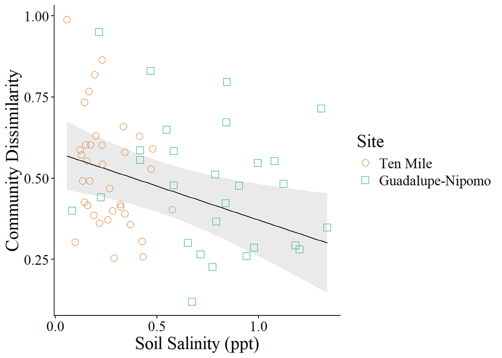

```r
Vars.Salin
```

# ** Tables **

```r
modelsummary(Lasso.plots.full)
```

|  | (1) |
| --- | --- |
| (Intercept) | 0.482 |
|  | (0.080) |
| Y | -0.000 |
|  | (0.000) |
| X | 0.001 |
|  | (0.001) |
| SoilTemp | 0.058 |
|  | (0.017) |
| Slope | 0.001 |
|  | (0.002) |
| Z | -0.010 |
|  | (0.011) |
| SoilMoist | 0.009 |
|  | (0.018) |
| SD (Intercept Site) | 0.073 |
| SD (Observations) | 0.164 |
| Num.Obs. | 107 |
| R2 Marg. | 0.116 |
| R2 Cond. | 0.263 |
| AIC | -4.0 |
| BIC | 20.1 |
| ICC | 0.2 |
| RMSE | 0.16 |

```r
modelsummary(Lasso.vars.reduced)
```

|  | (1) |
| --- | --- |
| (Intercept) | 0.616 |
|  | (0.057) |
| salinity_ppt | -0.209 |
|  | (0.080) |
| SoilTemp | 0.064 |
|  | (0.022) |
| SoilMoist | 0.032 |
|  | (0.022) |
| SD (Intercept Site) | 0.049 |
| SD (Observations) | 0.165 |
| Num.Obs. | 64 |
| R2 Marg. | 0.253 |
| R2 Cond. | 0.314 |
| AIC | -18.9 |
| BIC | -5.9 |
| ICC | 0.1 |
| RMSE | 0.16 |

```r
models.plots<- list(
  "All Plots (winner)" = Lasso.plots.reduced,
  "All Plots (full)" = Lasso.plots.full,
  "All Plots (Reduceder)" = Lasso.plots.reduceder,
  "All Plots (Null)" = Lasso.plots.null
   )


models.vars<- list(
  "All Variables (Winner)" = Lasso.vars.reduced,
  "All Variables (full)" = Lasso.vars.full,
  "All Variables (null)" = Lasso.vars.null  )

fun <- function(model) data.frame("corrected" = round(cAIC4::cAIC(model)$caic, 2))


modelsummary(models.plots,
  fmt = 3,
  estimate  = "{estimate} [{conf.low}, {conf.high}]",
  statistic = NULL,
  conf_level = .90,
  gof_function = fun,
  gof_omit = 'AIC|BIC|ICC',
  output = "AllPlotsTable.docx")

modelsummary(models.vars,
  fmt = 3,
  estimate  = "{estimate} [{conf.low}, {conf.high}]",
  statistic = NULL,
  conf_level = .90,
  gof_omit = 'AIC|BIC|ICC',
  gof_function = fun,
  output = "AllVarsTable.docx")
cAIC(Lasso.vars.reduced, B = 100)$caic
```

```
## [1] -40.70672
```

# **Figure Construction**

```r
#ggarrange(Plots.Negl, Vars.Negl, Plots.ST, Vars.ST,  widths = 5)

legend<-get_legend(Plots.ST+    theme(legend.background = element_rect(colour = 'black', fill = 'white', linetype='solid')))
legend$grobs
```

[output not shown]

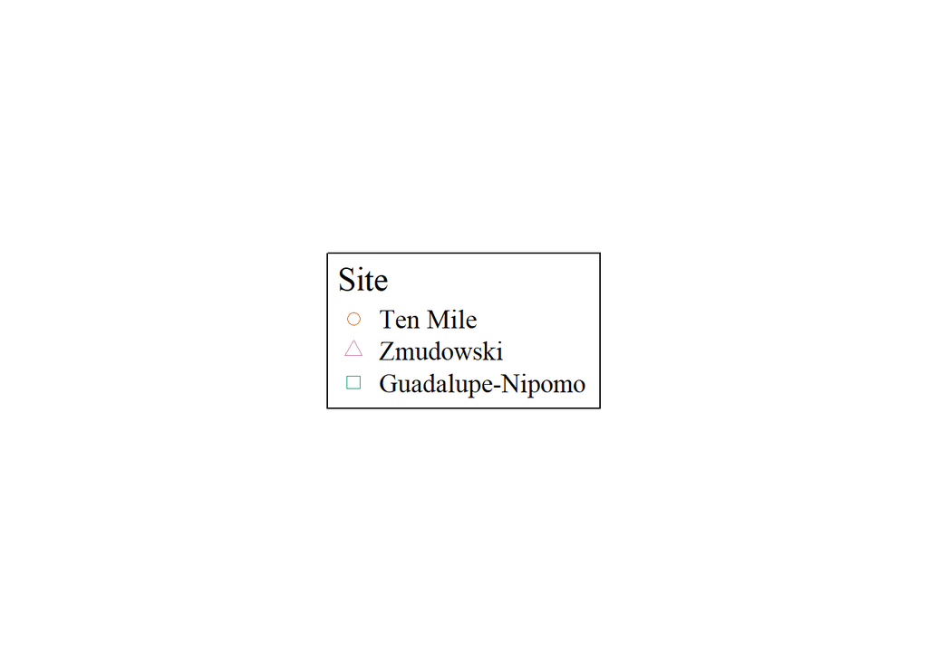

```r
leg<-plot_grid(legend)

leg
```

[figure not shown]

```r
Plots.ST2 <- Plots.ST+ theme(legend.position='bottom', legend.background = element_rect(colour = 'black', fill = 'white', linetype='solid'))
Vars.ST2<- Vars.ST+ theme(legend.position='none')
Vars.Salin2<- Vars.Salin+ theme(legend.position='none')



WithinGraphCombined<- ggdraw() +
  draw_plot(Plots.Negl, x = 0, y = .666, width = 0.5, height = .333) +
  draw_plot(Plots.ST2, x = 0, y = 0.288, width = 0.5, height = .378) +
  draw_plot(Vars.Negl, x = .5, y = .666, width = 0.5, height = 0.3333) +
  draw_plot(Vars.ST2, x = .5, y = 0.33333, width = 0.5, height = 0.3333) +
  draw_plot(Vars.Salin2, x = .5, y = 0, width = 0.5, height = 0.3333) +
  draw_image("WithinPlotLogo.png", x = 0.15, y = 0.04, width = .25, height = 0.25) +
  draw_plot_label(label = c("A", "C", "B", "D", "E"),family = "serif", size = 20, color = "black",
                  x = c(0, 0, 0.5, .5, .5), y = c(.9999, .69, 0.99999, .69,0.355 ))+
  draw_line(
    x = c(0.5, 0.5),
    y = c(.98, 0.02),
    color = "black", size = 1, linetype = 5, alpha = 0.5)+
  theme(plot.background = element_rect(fill = "white", color = "transparent"))
WithinGraphCombined
```

```r
ggsave( "WithinGraph.png", dpi = 600, height = 12, width = 15)
```

# **Conculsion**

This feels like a really justifiable and useful and interesing way to present these data at this level! Complicates things a smidge, but I think it is really worth it! However, let me know if there is something I’m not seeing here, but I’m pretty confident in defending it. Super cool and thank you for the kick in the pants!

-B

### Lil corplot

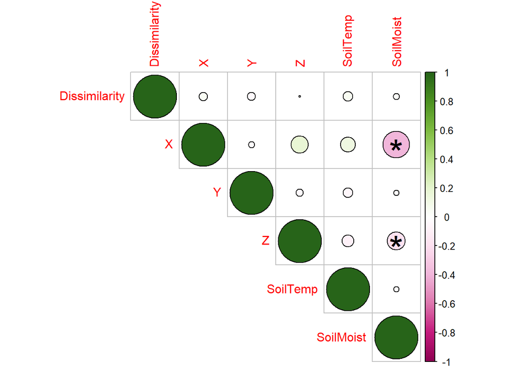

```r
library(corrplot)
library(Hmisc)
cor_dis<-Comb_Dis %>% select(Dissimilarity, X, Y, Z, SoilTemp, SoilMoist)

corr<-rcorr(as.matrix(cor_dis))

corrplot(corr$r, type = "upper", col = COL2('PiYG'), outline = TRUE, p.mat = corr$P %>% replace(is.na(.), 1), sig.level = 0.05, insig = "label_sig")
```

```r
save.image(file="DuneComm3.RData")
```